# Bureaucracy proj (demo)

Anastasiia Karpenko

18 09 2022

Dealing with government bureaucracy is not the most pleasant thing in the world. In this demo project I am looking at the association between the time the bureaucracy consumes and different economic indicators. In particular, to measure the bureaucracy I took the number of days and procedures one has to spend to register a property from the Doing Business Index.

I collected data for 145 countries for four years (2008, 2011, 2014, and 2017) from open resources like World Bank, Doing Business Index, International Labor Organization, etc.

## How does the bureaucracy associate with different economic indicators?

For example, a higher number of procedures one has to complete to register a property is associated with higher (lower) level of (absence) corruption, lower income and less democratic regimes.

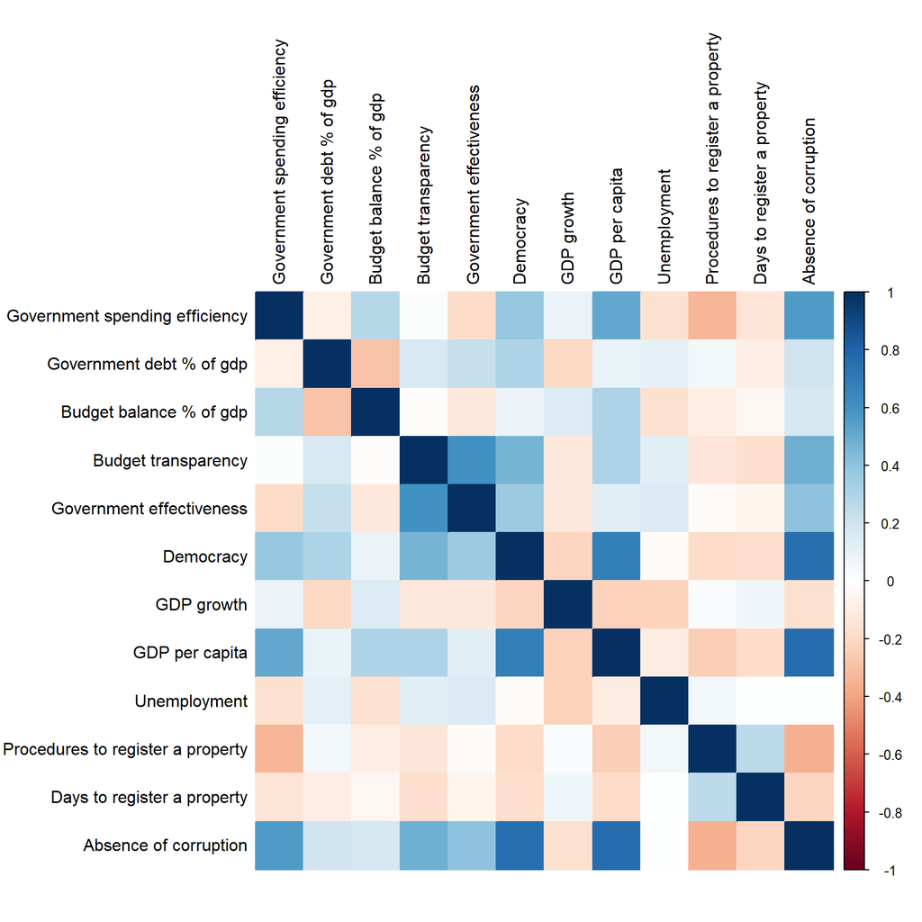

## Does more bureaucracy mean better spending of budget resources?

The figure below shows that more bureaucratic checks do not help much the government to distribute its finances more efficiently.

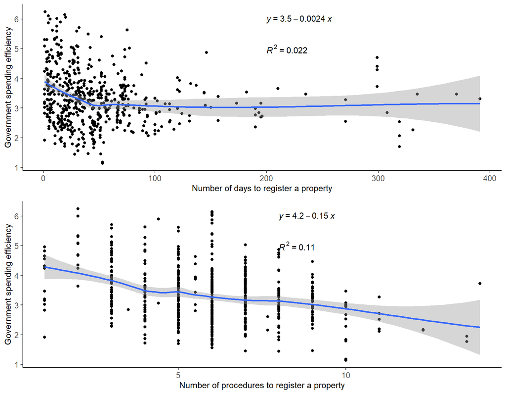

## What is the government spending efficiency per income group?

## What is the share of government debt to GDP per income group?

On average, countries that fell in a high-income group have higher efficiency of government spending as well as higher share of government debt to GDP.

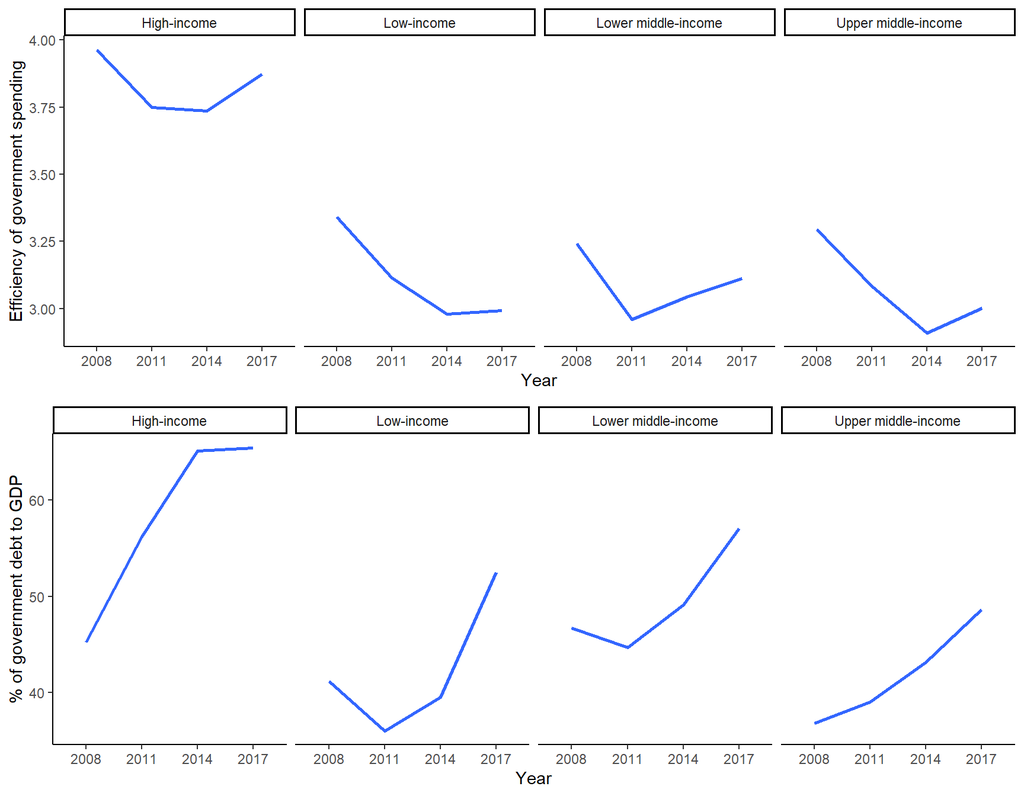